# R workshop

## 2 dimensions: homogenous elements

`matrix`

```r
matrix(data = 1:6, nrow = 2, ncol = 3)
```

```
##      [,1] [,2] [,3]
## [1,]    1    3    5
## [2,]    2    4    6
```

## 2 dimensions: data frames

which are `lists` where all columns have **equal** length

```r
class(iris)
## [1] "data.frame"
class(unclass(iris))
## [1] "list"
```

Actually, better to use `tbl_df` *tibble diff* [rstudio blog](https://blog.rstudio.org/2016/03/24/tibble-1-0-0/)

`data_frame()` does much less than `data.frame()`:

- never changes the type of the inputs (*e.g.* it never converts strings to factors!)
- never changes the names of variables
- never creates row.names()
- never print ALL rows

but display

- column types
- groups (`dplyr::group_by()`)

## subsetting data frames

data frame are lists

```r
mtcars[[1]]
```

```
##  [1] 21.0 21.0 22.8 21.4 18.7 18.1 14.3 24.4 22.8 19.2 17.8 16.4 17.3 15.2
## [15] 10.4 10.4 14.7 32.4 30.4 33.9 21.5 15.5 15.2 13.3 19.2 27.3 26.0 30.4
## [29] 15.8 19.7 15.0 21.4
```

```r
mtcars[["mpg"]]
```

```
##  [1] 21.0 21.0 22.8 21.4 18.7 18.1 14.3 24.4 22.8 19.2 17.8 16.4 17.3 15.2
## [15] 10.4 10.4 14.7 32.4 30.4 33.9 21.5 15.5 15.2 13.3 19.2 27.3 26.0 30.4
## [29] 15.8 19.7 15.0 21.4
```

but `$` is a shorthand for `[[`

```r
mtcars$mpg
```

```
##  [1] 21.0 21.0 22.8 21.4 18.7 18.1 14.3 24.4 22.8 19.2 17.8 16.4 17.3 15.2
## [15] 10.4 10.4 14.7 32.4 30.4 33.9 21.5 15.5 15.2 13.3 19.2 27.3 26.0 30.4
## [29] 15.8 19.7 15.0 21.4
```

## Rstudio

### Integrated Development Editor

## Layout, 4 panels

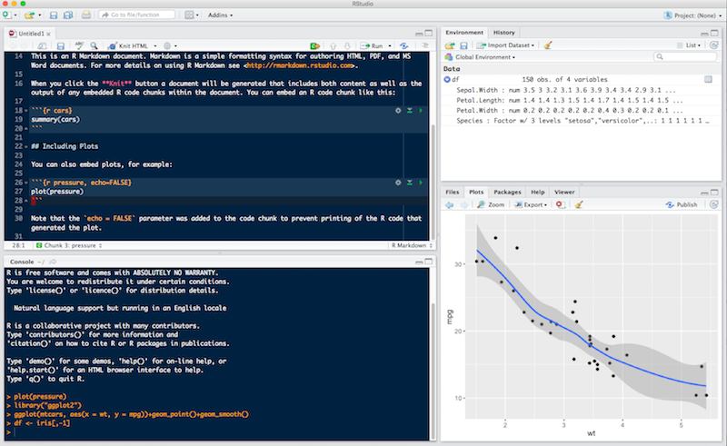

## Features

- Package management (including building)
- Console to run `R`, with syntax highligther
- Editor to work with scripts / markdown
- auto-completion using `TAB`
- Cheatsheets
- Keyboard shortcuts

`Cmd + Enter` (mac) or`Ctrl + Enter` (PC): sends the line or selection from the editor to the console and runs it.

`↑`: in the console browse previous commands

## Update options

Recommended in the [r4ds](http://r4ds.had.co.nz/introduction.html#prerequisites) To get a clean environment at start-up

[figure not shown]

## Projects

Solve most issues with working directories, get rid of `setwd()`

[figure not shown]

## Chaining

## The pipe operator %>%

[magrittr by Stefan Milton Bache](https://cran.r-project.org/web/packages/magrittr/vignettes/magrittr.html)

Compare:

```r
set.seed(124)
x <- rnorm(10)
mean(x)
```

```
## [1] 0.2147669
```

```r
round(mean(x), 3)
```

```
## [1] 0.215
```

with:

```r
set.seed(124)
rnorm(10) %>% mean %>% round(3)
```

```
## [1] 0.215
```

## Easier to read

natural from left to right.

Even better with **one** instruction per line and **indentation**

```r
set.seed(124)
rnorm(10) %>%
  mean %>%
  round(3)
```

```
## [1] 0.215
```

## placeholder = .

```r
x %>% f(.)
#stands for (pipe to the 1st function argument)
f(x)
```

When not 1st argument

```r
sub("b", "B", letters[1:3])
```

```
## [1] "a" "B" "c"
```

```r
letters[1:3] %>% sub("b", "B") # raises warning!
```

```
## [1] "B"
```

```r
letters[1:3] %>% sub("b", "B", .)
```

```
## [1] "a" "B" "c"
```

## Tidying data

### tidyr

## Definitions

- **Variable**: A quantity, quality, or property that you can measure.
- **Observation**: A set of values that display the relationship between variables. To be an observation, values need to be measured under similar conditions, usually measured on the same observational unit at the same time.
- **Value**: The state of a variable that you observe when you measure it.

[source: Garret Grolemund](http://garrettgman.github.io/tidying/)

## Rules

1. Each variable is in its own column
2. Each observation is in its own row
3. Each value is in its own cell

[figure not shown]

## Convert Long / wide format

The wide format is generally untidy *but* found in the majority of datasets

[figure not shown]

## Demo with the iris dataset

```r
head(iris, 3)
```

```
##   Sepal.Length Sepal.Width Petal.Length Petal.Width Species
## 1          5.1         3.5          1.4         0.2  setosa
## 2          4.9         3.0          1.4         0.2  setosa
## 3          4.7         3.2          1.3         0.2  setosa
```

gather

```r
library("tidyr")
iris_melt <- iris %>%
  tibble::rownames_to_column() %>%
  dplyr::tbl_df() %>%
  gather(flower, measure, contains("al"))
iris_melt
```

```
## Source: local data frame [600 x 4]
##
##    rowname Species       flower measure
##      <chr>  <fctr>        <chr>   <dbl>
## 1        1  setosa Sepal.Length     5.1
## 2        2  setosa Sepal.Length     4.9
## 3        3  setosa Sepal.Length     4.7
## 4        4  setosa Sepal.Length     4.6
## 5        5  setosa Sepal.Length     5.0
## 6        6  setosa Sepal.Length     5.4
## 7        7  setosa Sepal.Length     4.6
## 8        8  setosa Sepal.Length     5.0
## 9        9  setosa Sepal.Length     4.4
## 10      10  setosa Sepal.Length     4.9
## ..     ...     ...          ...     ...
```

spread

```r
iris_melt %>%
  spread(flower, measure)
```

```
## Source: local data frame [150 x 6]
##
##    rowname    Species Petal.Length Petal.Width Sepal.Length Sepal.Width
##      <chr>     <fctr>        <dbl>       <dbl>        <dbl>       <dbl>
## 1        1     setosa          1.4         0.2          5.1         3.5
## 2       10     setosa          1.5         0.1          4.9         3.1
## 3      100 versicolor          4.1         1.3          5.7         2.8
## 4      101  virginica          6.0         2.5          6.3         3.3
## 5      102  virginica          5.1         1.9          5.8         2.7
## 6      103  virginica          5.9         2.1          7.1         3.0
## 7      104  virginica          5.6         1.8          6.3         2.9
## 8      105  virginica          5.8         2.2          6.5         3.0
## 9      106  virginica          6.6         2.1          7.6         3.0
## 10     107  virginica          4.5         1.7          4.9         2.5
## ..     ...        ...          ...         ...          ...         ...
```

## Separate / Unite

unite

```r
df %>%
  unite(date, c(year, month, day), sep = "-") -> df_unite
```

separate, use **quotes** since we are not refering to objects

```r
df_unite %>%
  separate(date, c("year", "month", "day"))
```

```
## Source: local data frame [3 x 4]
##
##    year month   day value
##   <chr> <chr> <chr> <chr>
## 1  2015    11    23  high
## 2  2014     2     1   low
## 3  2014     4    30   low
```

## Help

using `?` or `help()`

```r
?gather
```

or using the `Help` tab next to the `Packages` tab.

## Reading data

### readr

## read_tsv

Guess column types and give **warnings**.

```r
library("readr")
soft <- read_tsv("data/GDS5079.soft", skip = 42, na = "null")
```

```
## Warning: 2 parsing failures.
##   row      col   expected             actual
## 35557 10344614 an integer !dataset_table_end
## 35557 NA       6 columns  1 columns
```

Viewer utility

```r
View(soft)
```

## Easier: import file utility

Using `Rstudio`, right top panel. Select directly your **file**. This actually uses **readr**.

[figure not shown]

## Plotting

### ggplot2

[overview](http://rvisualization.com/ggplot2-overview-2/)

## Why tidy is useful?

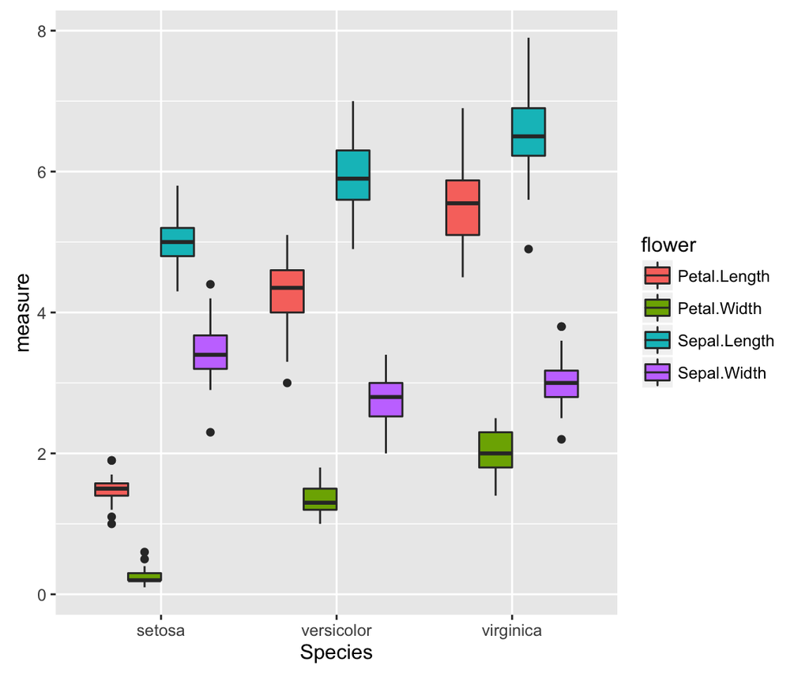

```r
library("tidyr")
library("ggplot2")
iris %>%
  gather(flower, measure, 1:4) %>%
  ggplot()+
  geom_boxplot(aes(x = Species, y = measure, fill = flower))
```

## Scatterplots

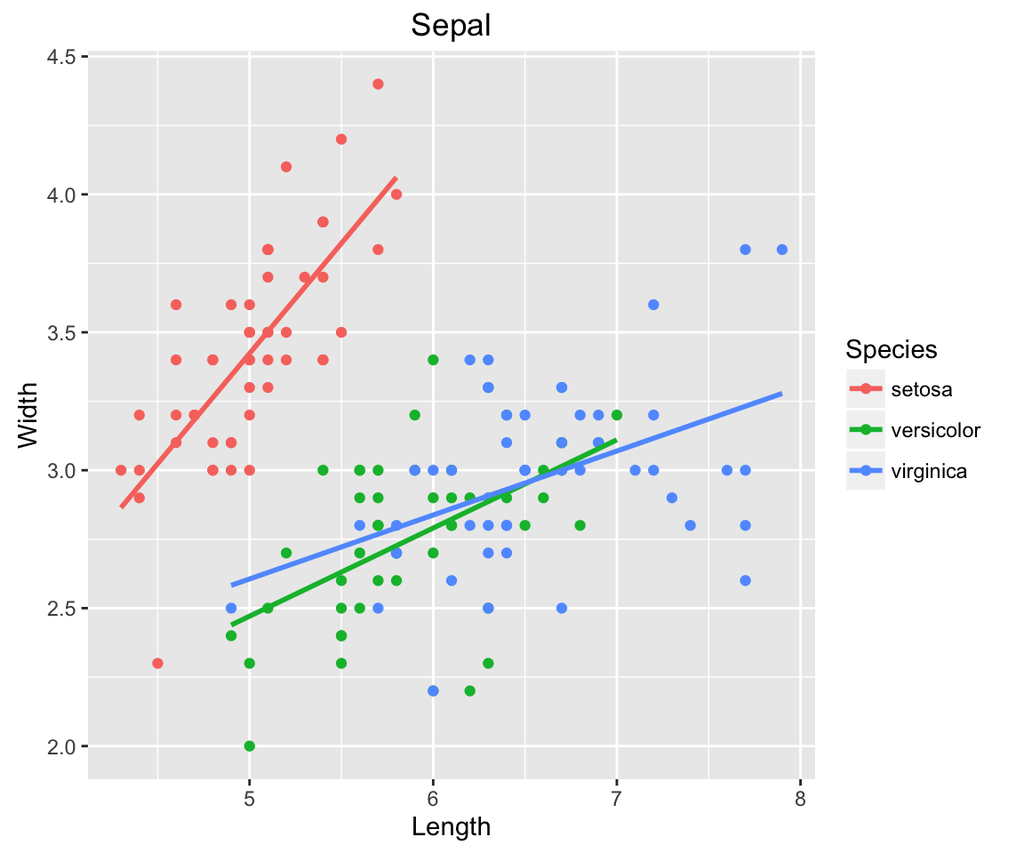

```r
iris %>%
  ggplot(aes(x = Sepal.Length, y = Sepal.Width, colour = Species))+
  geom_point()+
  geom_smooth(method = "lm", se = FALSE)+
  xlab("Length")+
  ylab("Width")+
  ggtitle("Sepal")
```

## More aesthetics

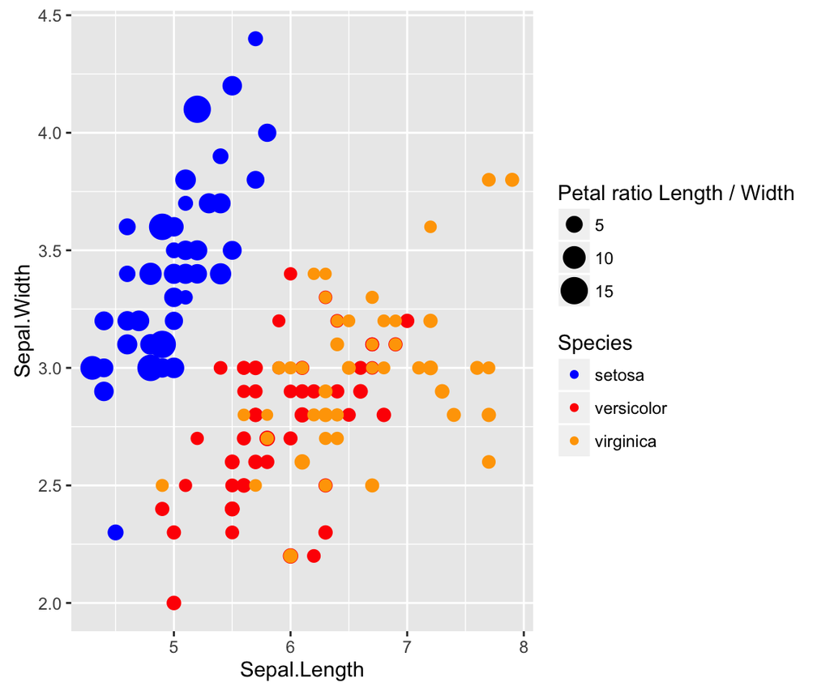

```r
iris %>%
  ggplot(aes(x = Sepal.Length, y = Sepal.Width,
             size = Petal.Length / Petal.Width,
             colour = Species))+
  geom_point()+
  scale_size_area("Petal ratio Length / Width")+
  #scale_colour_brewer(palette = 1, type = "qual")+
  scale_colour_manual(values = c("blue", "red", "orange"))+
  xlab("Sepal.Length")+
  ylab("Sepal.Width")
```

## in / out aesthetics

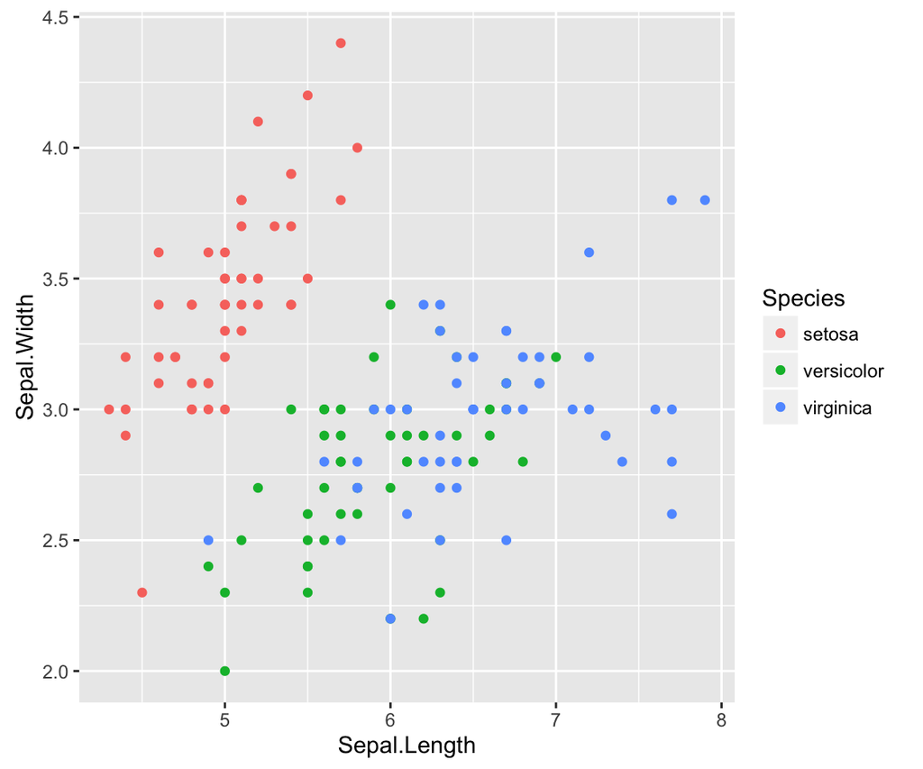

```r
iris %>%
  ggplot(aes(x = Sepal.Length, y = Sepal.Width))+
  geom_point(aes(colour = Species))
```

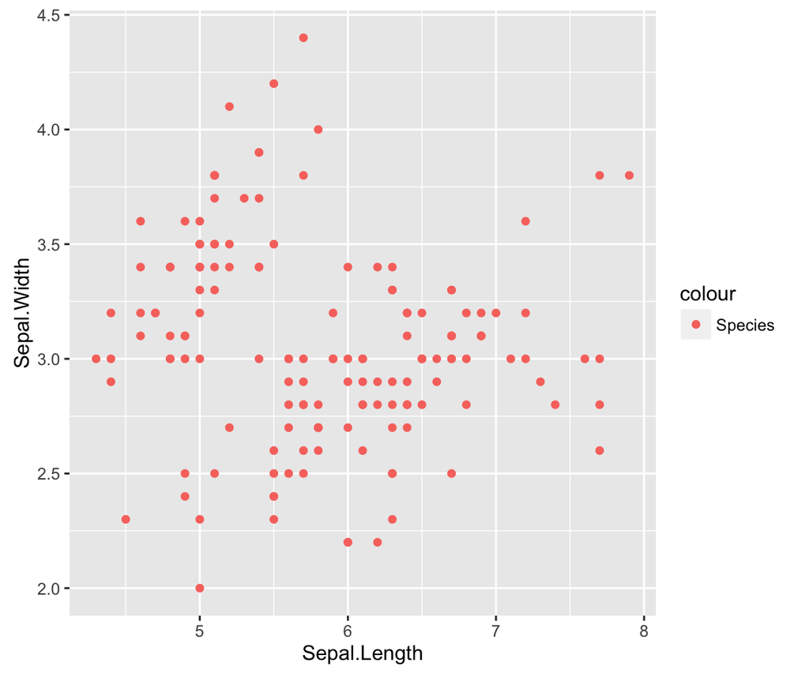

```r
iris %>%
  ggplot(aes(x = Sepal.Length, y = Sepal.Width))+
  geom_point(aes(colour = "Species"))
```

## in / out aesthetics

```r
iris %>%
  ggplot(aes(x = Sepal.Length, y = Sepal.Width))+
  geom_point(colour = "Species") # Error
```

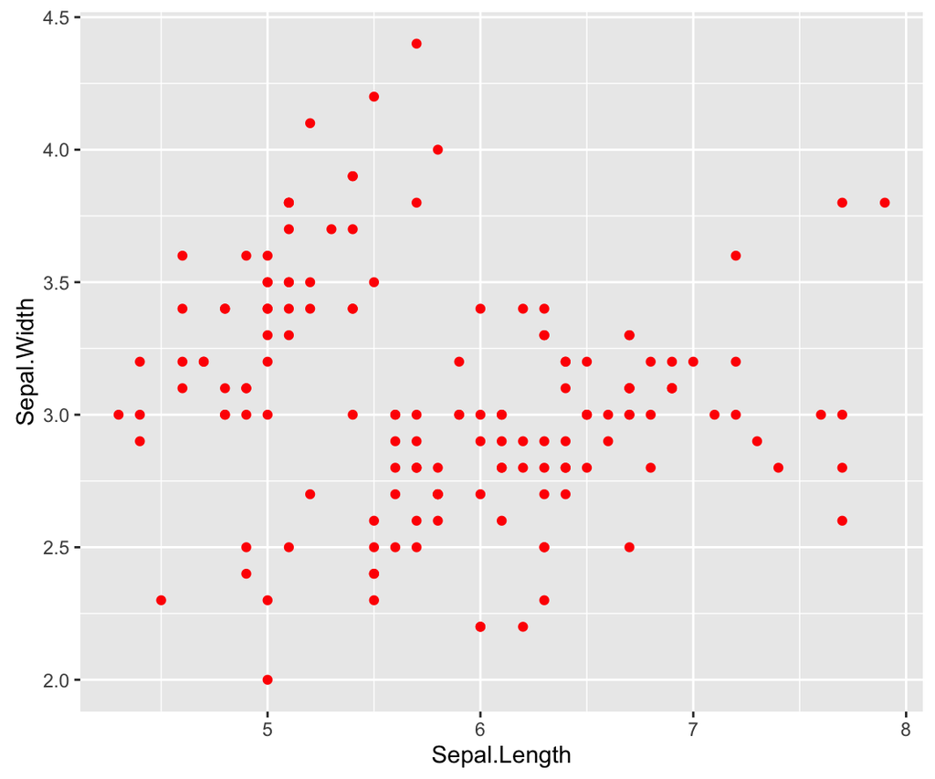

```r
iris %>%
  ggplot(aes(x = Sepal.Length, y = Sepal.Width))+
  geom_point(colour = "red")
```

## histogram

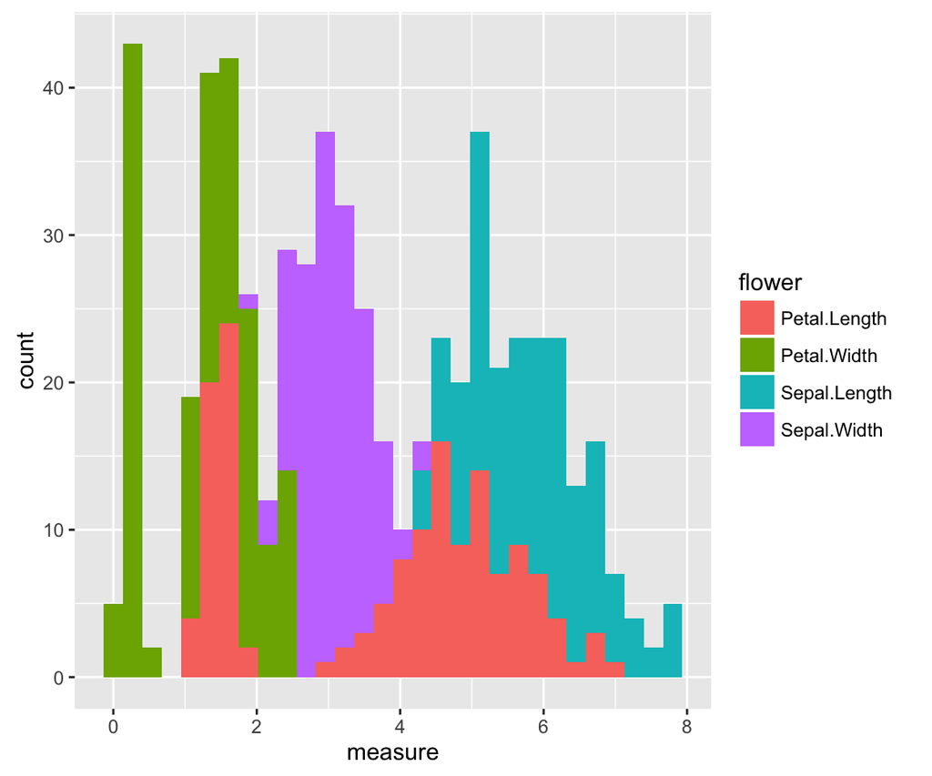

```r
iris_melt %>%
  ggplot()+
  geom_histogram(aes(x = measure, fill = flower))
```

## Barplots - stack

by default, `geom_bar` counts. For mapping values use `stat = "identity"`

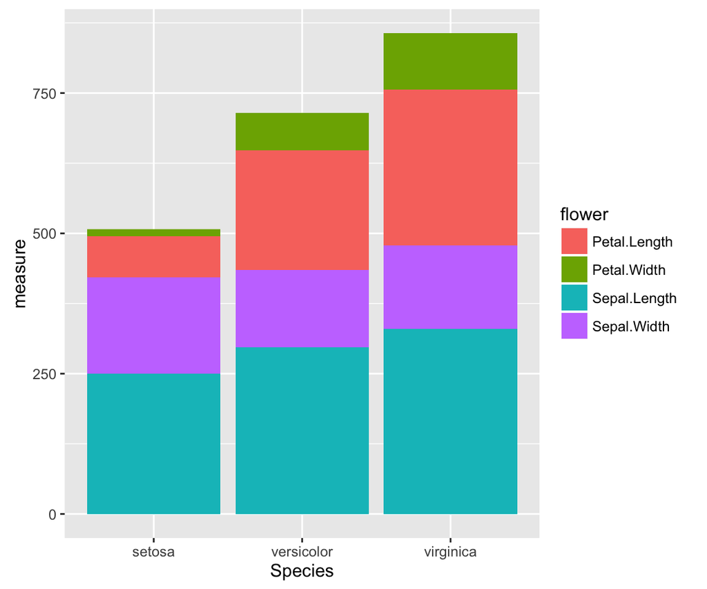

```r
iris_melt %>%
  ggplot()+
  geom_bar(aes(x = Species, y = measure, fill = flower), stat = "identity")
```

```r
iris_melt %>%
  ggplot()+
  geom_bar(aes(x = measure, fill = flower))
```

## Barplots - relative

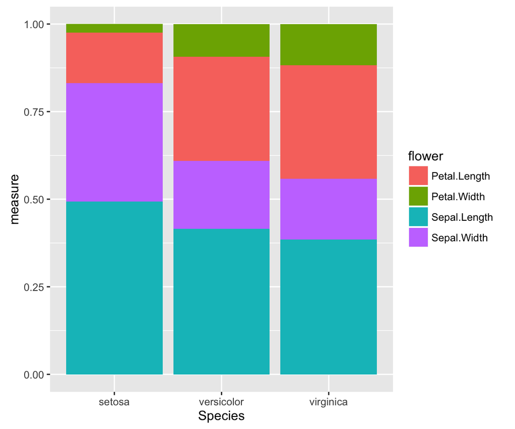

```r
iris_melt %>%
  ggplot()+
  geom_bar(aes(x = Species, y = measure, fill = flower), position = "fill", stat = "identity")
```

## Barplots - dodge

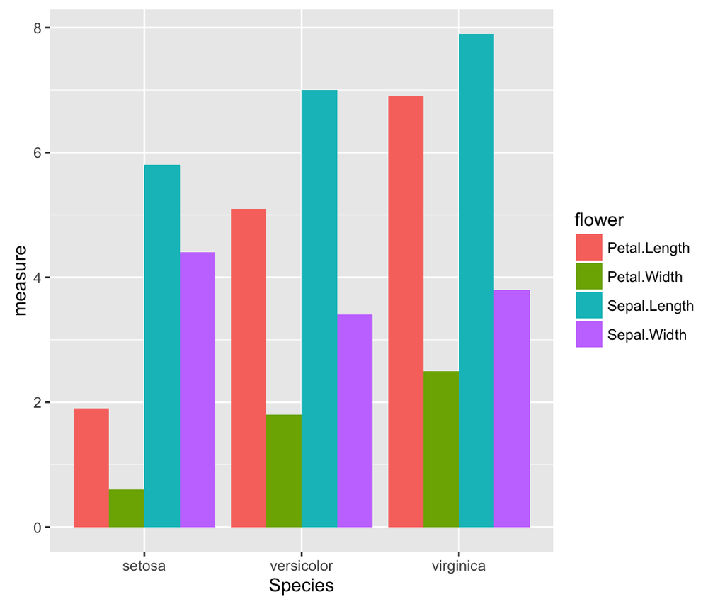

```r
iris_melt %>%
  ggplot()+
  geom_bar(aes(x = Species, y = measure, fill = flower), position = "dodge", stat = "identity")
```

## heatmap

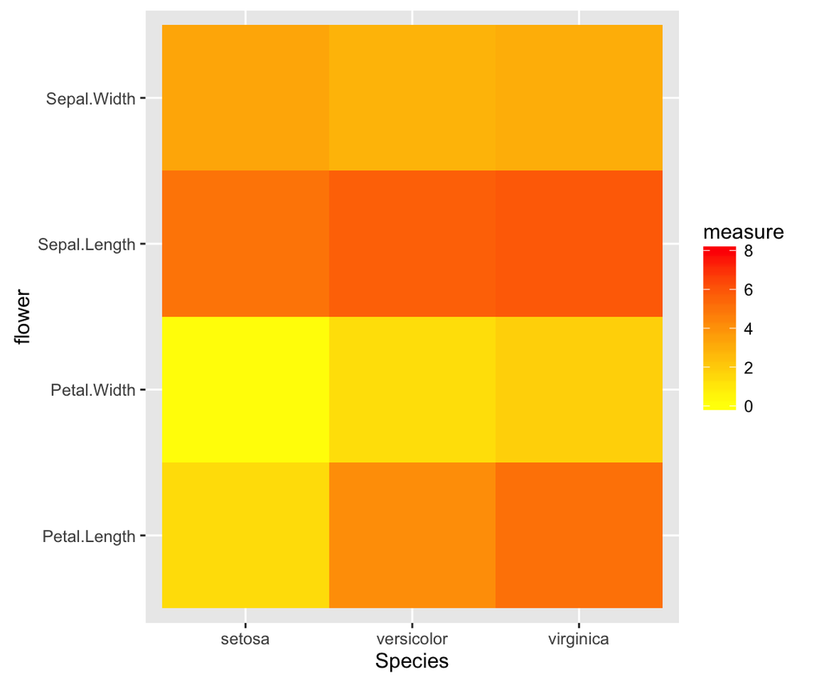

```r
iris_melt %>%
  ggplot()+
  geom_tile(aes(x = Species, y = flower, fill = measure))+
  scale_fill_gradient(low = "yellow", high = "red", limits = c(0, 8))
```

## Density and faceting

transparency using the `alpha` parameter

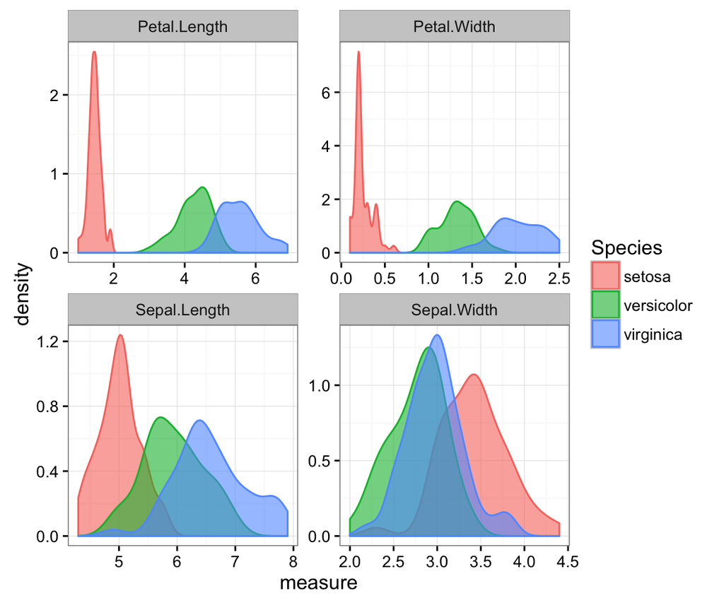

```r
iris_melt %>%
  ggplot()+
  geom_density(aes(x = measure, fill = Species, colour = Species), alpha = 0.6)+
  facet_wrap(~ flower, scale = "free")+
  theme_bw()
```

## facetting

transparency using the `alpha` parameter

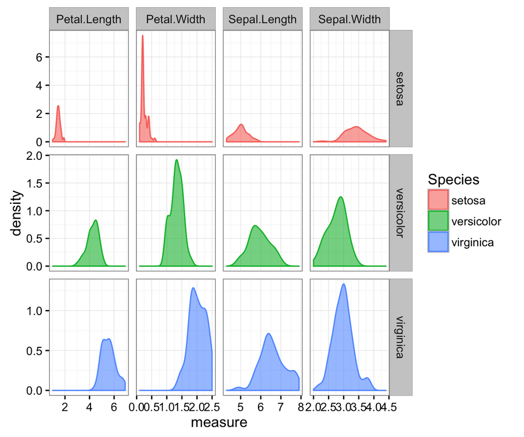

```r
iris_melt %>%
  ggplot()+
  geom_density(aes(x = measure, fill = Species, colour = Species), alpha = 0.6)+
  facet_grid(Species ~ flower, scale = "free")+
  theme_bw()
```

## theme

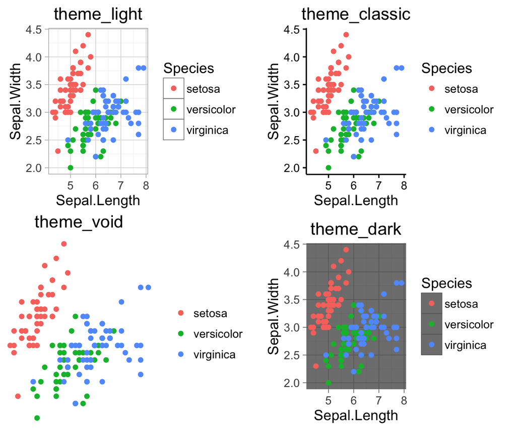

## Recommended reading

- [data structures](http://adv-r.had.co.nz/Data-structures.html) by Hadley
- [R for data science](http://r4ds.had.co.nz) by Hadley & Garrett
- [reading data](http://r4ds.had.co.nz/data-import.html)
- [tidy data](http://r4ds.had.co.nz/tidy-data.html)
- [plotting](http://r4ds.had.co.nz/data-visualisation.html)
- [ggplot2 documentation](http://docs.ggplot2.org/current/) by Hadley / Winston
- [ggplot2 layer by layer](http://rpubs.com/hadley/ggplot2-layers) by Hadley
- [ggplot2 extensions](https://www.ggplot2-exts.org/) by Daniel Emaasit
- Excellent ressource on `R` (in French) [Introduction to R](http://egallic.fr/Enseignement/R/m1_stat_eco_logiciel_R.pdf) by Ewen Gallic

## Acknowledgments

- Hadley Wickham
- Garrett Grolemund
- Jenny Bryan
- Ewen Gallic
- David Robinson
- Eric Koncina
- Tony Heurtaux